# Analyzing and Visualizing WeRateDogs Dataset

### Table of content

- Introduction
- Analysis and Visualization
- Conclusion

## Introduction

Have you heard about the twitter account WeRateDogs ? Prabably yes, but if not. Here I will present a little bit about it and more than that I will show some funny analysis of some tweets data.

WeRateDogs is a twitter account that rates people's dog with a lot of humor, showing funny pictures and comments and a unique rating level. These ratings most of time have a denominator of 10, but the numerators are almost grather than 10.

This twitter page has over than 8 million followers and has received international media coverage. Its most famous meme is "*they're good dogs Brent*" and since November 2015 this page is filling his followers with joy.

So whats does this rating mean? Which dog type is most common in the tweets dataframe? What dog type has the highest average rating? These questions will be answered during this report.

## Analysis and Visualization

### Firt insight

After analyze around 1600+ tweets over 12000+ of WeRateDogs page, Golden retriever is the most common dog in the dataframe with more 113 dog types.

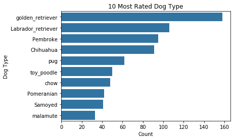

```python
top_10 = df_twitter.prediction.value_counts().sort_values(ascending=False)[0:10].index
df_top = df_twitter[df_twitter['prediction'].isin(top_10)]
base_color = sb.color_palette()[0]
sb.countplot(data = df_top, y = 'prediction', color = base_color, order = df_top.prediction.value_counts().index)
plt.xlabel('Count')
plt.ylabel('Dog Type')
plt.title('10 Most Rated Dog Type');
```

### Secod insight

The most retweeted and liked tweet is about a Labrador Retriever in a swimming pool and the last is about an English Setter with her puppies.

1. [Labrador Retriever swimming tweet link](https://twitter.com/dog_rates/status/744234799360020481/video/1)
2. [English Setter with puppies tweet link](https://twitter.com/dog_rates/status/666102155909144576/photo/1)

This is the most retweeted and liked tweet of the entire dataset

[figure not shown]

```python
from IPython.display import Image
Image('labrador.JPG')
```

This is the last retweeted and liked tweet of the entire dataset

[figure not shown]

```python
Image('setter.JPG')
```

### Third insight

Bouvier_des_Flandres has the best average rating of all types of dogs while Japanese_spaniel has the worst. Although they have the first and the last averages, we need to confirm that these values are representative.

```python
statistics.sort_values('mean', ascending=False)
```

|  | prediction | count | mean | std | min | 25% | 50% | 75% | max |
| --- | --- | --- | --- | --- | --- | --- | --- | --- | --- |
| 11 | Bouvier_des_Flandres | 1.0 | 1.300000 | NaN | 1.3 | 1.30 | 1.3 | 1.300 | 1.3 |
| 54 | Saluki | 4.0 | 1.250000 | 0.100000 | 1.1 | 1.25 | 1.3 | 1.300 | 1.3 |
| 78 | briard | 3.0 | 1.233333 | 0.057735 | 1.2 | 1.20 | 1.2 | 1.250 | 1.3 |
| 63 | Tibetan_mastiff | 4.0 | 1.225000 | 0.050000 | 1.2 | 1.20 | 1.2 | 1.225 | 1.3 |
| 9 | Border_terrier | 7.0 | 1.214286 | 0.069007 | 1.1 | 1.20 | 1.2 | 1.250 | 1.3 |
| ... | ... | ... | ... | ... | ... | ... | ... | ... | ... |
| 64 | Tibetan_terrier | 4.0 | 0.925000 | 0.206155 | 0.7 | 0.85 | 0.9 | 0.975 | 1.2 |
| 65 | Walker_hound | 5.0 | 0.900000 | 0.173205 | 0.6 | 0.90 | 1.0 | 1.000 | 1.0 |
| 56 | Scotch_terrier | 1.0 | 0.900000 | NaN | 0.9 | 0.90 | 0.9 | 0.900 | 0.9 |
| 105 | soft-coated_wheaten_terrier | 15.0 | 0.880000 | 0.312136 | 0.3 | 0.70 | 1.0 | 1.100 | 1.3 |
| 36 | Japanese_spaniel | 1.0 | 0.500000 | NaN | 0.5 | 0.50 | 0.5 | 0.500 | 0.5 |

113 rows × 9 columns

### Fourth insight

After cheking the scatter chart we can say that the best and worst rating average for dog types do not represent the truth as these averages are calculated with a few tweets.

[figure not shown]

```python
plt.scatter(data=statistics, x='count', y='mean')
plt.xlabel('Count')
plt.ylabel('Mean')
plt.title('Count x Mean in Dog Types Statistics');
```

## Conclusion

After analyze this data we can say that many other questions can be asked and solved during a data analysis and a lot of fun can be found in this or another dataset.